# Risk Factor Analysis

## Outcome Variable

**Outcome Variable:** wast_rec90d

## Predictor Variables

**Intervention Variable:** hfoodsec

**Adjustment Set:**

unadjusted

## Stratifying Variables

The analysis was stratified on these variable(s):

- agecat
- studyid
- country

## Data Summary

| agecat | studyid | country | hfoodsec | wast_rec90d | n_cell | n |
| --- | --- | --- | --- | --- | --- | --- |
| 0-24 months | GMS-Nepal | NEPAL | Food Secure | 0 | 201 | 624 |
| 0-24 months | GMS-Nepal | NEPAL | Food Secure | 1 | 251 | 624 |
| 0-24 months | GMS-Nepal | NEPAL | Mildly Food Insecure | 0 | 37 | 624 |
| 0-24 months | GMS-Nepal | NEPAL | Mildly Food Insecure | 1 | 42 | 624 |
| 0-24 months | GMS-Nepal | NEPAL | Food Insecure | 0 | 46 | 624 |
| 0-24 months | GMS-Nepal | NEPAL | Food Insecure | 1 | 47 | 624 |
| 0-24 months | JiVitA-3 | BANGLADESH | Food Secure | 0 | 1604 | 5644 |
| 0-24 months | JiVitA-3 | BANGLADESH | Food Secure | 1 | 1031 | 5644 |
| 0-24 months | JiVitA-3 | BANGLADESH | Mildly Food Insecure | 0 | 1185 | 5644 |
| 0-24 months | JiVitA-3 | BANGLADESH | Mildly Food Insecure | 1 | 714 | 5644 |
| 0-24 months | JiVitA-3 | BANGLADESH | Food Insecure | 0 | 729 | 5644 |
| 0-24 months | JiVitA-3 | BANGLADESH | Food Insecure | 1 | 381 | 5644 |
| 0-24 months | JiVitA-4 | BANGLADESH | Food Secure | 0 | 763 | 2053 |
| 0-24 months | JiVitA-4 | BANGLADESH | Food Secure | 1 | 265 | 2053 |
| 0-24 months | JiVitA-4 | BANGLADESH | Mildly Food Insecure | 0 | 561 | 2053 |
| 0-24 months | JiVitA-4 | BANGLADESH | Mildly Food Insecure | 1 | 204 | 2053 |
| 0-24 months | JiVitA-4 | BANGLADESH | Food Insecure | 0 | 200 | 2053 |
| 0-24 months | JiVitA-4 | BANGLADESH | Food Insecure | 1 | 60 | 2053 |
| 0-24 months | MAL-ED | BANGLADESH | Food Secure | 0 | 31 | 100 |
| 0-24 months | MAL-ED | BANGLADESH | Food Secure | 1 | 49 | 100 |
| 0-24 months | MAL-ED | BANGLADESH | Mildly Food Insecure | 0 | 1 | 100 |
| 0-24 months | MAL-ED | BANGLADESH | Mildly Food Insecure | 1 | 2 | 100 |
| 0-24 months | MAL-ED | BANGLADESH | Food Insecure | 0 | 6 | 100 |
| 0-24 months | MAL-ED | BANGLADESH | Food Insecure | 1 | 11 | 100 |
| 0-24 months | MAL-ED | BRAZIL | Food Secure | 0 | 0 | 15 |
| 0-24 months | MAL-ED | BRAZIL | Food Secure | 1 | 0 | 15 |
| 0-24 months | MAL-ED | BRAZIL | Mildly Food Insecure | 0 | 0 | 15 |
| 0-24 months | MAL-ED | BRAZIL | Mildly Food Insecure | 1 | 0 | 15 |
| 0-24 months | MAL-ED | BRAZIL | Food Insecure | 0 | 3 | 15 |
| 0-24 months | MAL-ED | BRAZIL | Food Insecure | 1 | 12 | 15 |

[output cut: 168 more lines]

The following strata were considered:

- agecat: 0-24 months, studyid: GMS-Nepal, country: NEPAL
- agecat: 0-24 months, studyid: JiVitA-3, country: BANGLADESH
- agecat: 0-24 months, studyid: JiVitA-4, country: BANGLADESH
- agecat: 0-24 months, studyid: MAL-ED, country: BANGLADESH
- agecat: 0-24 months, studyid: MAL-ED, country: BRAZIL
- agecat: 0-24 months, studyid: MAL-ED, country: INDIA
- agecat: 0-24 months, studyid: MAL-ED, country: NEPAL
- agecat: 0-24 months, studyid: MAL-ED, country: PERU
- agecat: 0-24 months, studyid: MAL-ED, country: SOUTH AFRICA
- agecat: 0-24 months, studyid: NIH-Birth, country: BANGLADESH
- agecat: 0-24 months, studyid: NIH-Crypto, country: BANGLADESH
- agecat: 0-6 months, studyid: GMS-Nepal, country: NEPAL
- agecat: 0-6 months, studyid: JiVitA-3, country: BANGLADESH
- agecat: 0-6 months, studyid: JiVitA-4, country: BANGLADESH
- agecat: 0-6 months, studyid: MAL-ED, country: BANGLADESH
- agecat: 0-6 months, studyid: MAL-ED, country: BRAZIL
- agecat: 0-6 months, studyid: MAL-ED, country: INDIA
- agecat: 0-6 months, studyid: MAL-ED, country: NEPAL
- agecat: 0-6 months, studyid: MAL-ED, country: PERU
- agecat: 0-6 months, studyid: MAL-ED, country: SOUTH AFRICA
- agecat: 0-6 months, studyid: NIH-Birth, country: BANGLADESH
- agecat: 0-6 months, studyid: NIH-Crypto, country: BANGLADESH
- agecat: 6-24 months, studyid: GMS-Nepal, country: NEPAL
- agecat: 6-24 months, studyid: JiVitA-3, country: BANGLADESH
- agecat: 6-24 months, studyid: JiVitA-4, country: BANGLADESH
- agecat: 6-24 months, studyid: MAL-ED, country: BANGLADESH
- agecat: 6-24 months, studyid: MAL-ED, country: BRAZIL
- agecat: 6-24 months, studyid: MAL-ED, country: INDIA
- agecat: 6-24 months, studyid: MAL-ED, country: NEPAL
- agecat: 6-24 months, studyid: MAL-ED, country: PERU
- agecat: 6-24 months, studyid: MAL-ED, country: SOUTH AFRICA
- agecat: 6-24 months, studyid: NIH-Birth, country: BANGLADESH
- agecat: 6-24 months, studyid: NIH-Crypto, country: BANGLADESH

### Dropped Strata

Some strata were dropped due to rare outcomes:

- agecat: 0-24 months, studyid: MAL-ED, country: BANGLADESH
- agecat: 0-24 months, studyid: MAL-ED, country: BRAZIL
- agecat: 0-24 months, studyid: MAL-ED, country: INDIA
- agecat: 0-24 months, studyid: MAL-ED, country: NEPAL
- agecat: 0-24 months, studyid: MAL-ED, country: PERU
- agecat: 0-24 months, studyid: MAL-ED, country: SOUTH AFRICA
- agecat: 0-6 months, studyid: MAL-ED, country: BANGLADESH
- agecat: 0-6 months, studyid: MAL-ED, country: BRAZIL
- agecat: 0-6 months, studyid: MAL-ED, country: INDIA
- agecat: 0-6 months, studyid: MAL-ED, country: NEPAL
- agecat: 0-6 months, studyid: MAL-ED, country: PERU
- agecat: 0-6 months, studyid: MAL-ED, country: SOUTH AFRICA
- agecat: 0-6 months, studyid: NIH-Crypto, country: BANGLADESH
- agecat: 6-24 months, studyid: JiVitA-3, country: BANGLADESH
- agecat: 6-24 months, studyid: MAL-ED, country: BANGLADESH
- agecat: 6-24 months, studyid: MAL-ED, country: BRAZIL
- agecat: 6-24 months, studyid: MAL-ED, country: INDIA
- agecat: 6-24 months, studyid: MAL-ED, country: NEPAL
- agecat: 6-24 months, studyid: MAL-ED, country: PERU
- agecat: 6-24 months, studyid: MAL-ED, country: SOUTH AFRICA
- agecat: 6-24 months, studyid: NIH-Birth, country: BANGLADESH
- agecat: 6-24 months, studyid: NIH-Crypto, country: BANGLADESH

## Methods Detail

We’re interested in the causal parameters $E[Y_a]$ for all values of $a \in \mathcal{A}$. These parameters represent the mean outcome if, possibly contrary to fact, we intervened to set all units to have $A=a$. Under the randomization and positivity assumptions, these are identified by the statistical parameters $\psi_a=E_W[E_{Y|A,W}(Y|A=a,W)]$. In addition, we’re interested in the mean of $Y$, $E[Y]$ under no intervention (the observed mean). We will estimate these parameters by using SuperLearner to fit the relevant likelihood factors – $E_{Y|A,W}(Y|A=a,W)$ and $p(A=a|W)$, and then updating our likelihood fit using a joint TMLE.

For unadjusted analyses ($W=\{\}$), initial likelihoods were estimated using Lrnr_glm to estimate the simple $E(Y|A)$ and Lrnr_mean to estimate $p(A)$. For adjusted analyses, a small library containing Lrnr_glmnet, Lrnr_xgboost, and Lrnr_mean was used.

Having estimated these parameters, we will then use the delta method to estimate relative risks and attributable risks relative to a prespecified baseline level of $A$.

# Results Detail

## Results Plots

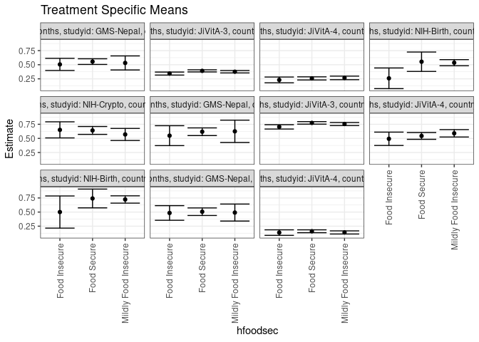

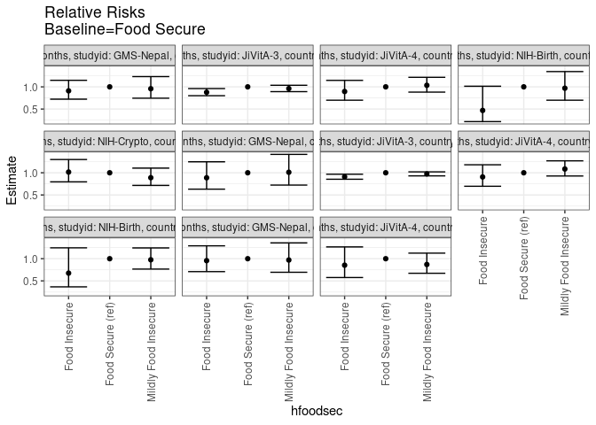

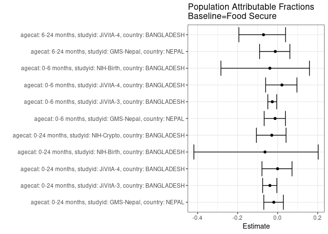

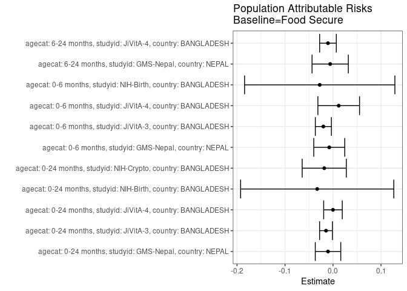

## Results Table

### Parameter: TSM

| agecat | studyid | country | intervention_level | baseline_level | estimate | ci_lower | ci_upper |
| --- | --- | --- | --- | --- | --- | --- | --- |
| 0-24 months | GMS-Nepal | NEPAL | Food Secure | NA | 0.5553097 | 0.5048934 | 0.6057261 |
| 0-24 months | GMS-Nepal | NEPAL | Mildly Food Insecure | NA | 0.5316456 | 0.4071454 | 0.6561458 |
| 0-24 months | GMS-Nepal | NEPAL | Food Insecure | NA | 0.5053763 | 0.3979319 | 0.6128208 |
| 0-24 months | JiVitA-3 | BANGLADESH | Food Secure | NA | 0.3912713 | 0.3726283 | 0.4099144 |
| 0-24 months | JiVitA-3 | BANGLADESH | Mildly Food Insecure | NA | 0.3759874 | 0.3543278 | 0.3976469 |
| 0-24 months | JiVitA-3 | BANGLADESH | Food Insecure | NA | 0.3432432 | 0.3164520 | 0.3700345 |
| 0-24 months | JiVitA-4 | BANGLADESH | Food Secure | NA | 0.2577821 | 0.2298644 | 0.2856998 |
| 0-24 months | JiVitA-4 | BANGLADESH | Mildly Food Insecure | NA | 0.2666667 | 0.2350779 | 0.2982554 |
| 0-24 months | JiVitA-4 | BANGLADESH | Food Insecure | NA | 0.2307692 | 0.1795409 | 0.2819975 |
| 0-24 months | NIH-Birth | BANGLADESH | Food Secure | NA | 0.5531915 | 0.3813656 | 0.7250173 |
| 0-24 months | NIH-Birth | BANGLADESH | Mildly Food Insecure | NA | 0.5360231 | 0.4817521 | 0.5902940 |
| 0-24 months | NIH-Birth | BANGLADESH | Food Insecure | NA | 0.2592593 | 0.0762417 | 0.4422768 |
| 0-24 months | NIH-Crypto | BANGLADESH | Food Secure | NA | 0.6408840 | 0.5711045 | 0.7106635 |
| 0-24 months | NIH-Crypto | BANGLADESH | Mildly Food Insecure | NA | 0.5697674 | 0.4629077 | 0.6766272 |
| 0-24 months | NIH-Crypto | BANGLADESH | Food Insecure | NA | 0.6511628 | 0.5085212 | 0.7938043 |
| 0-6 months | GMS-Nepal | NEPAL | Food Secure | NA | 0.6180905 | 0.5500694 | 0.6861115 |
| 0-6 months | GMS-Nepal | NEPAL | Mildly Food Insecure | NA | 0.6250000 | 0.4270268 | 0.8229732 |
| 0-6 months | GMS-Nepal | NEPAL | Food Insecure | NA | 0.5483871 | 0.3717297 | 0.7250445 |
| 0-6 months | JiVitA-3 | BANGLADESH | Food Secure | NA | 0.7746056 | 0.7521459 | 0.7970652 |
| 0-6 months | JiVitA-3 | BANGLADESH | Mildly Food Insecure | NA | 0.7547569 | 0.7273705 | 0.7821432 |
| 0-6 months | JiVitA-3 | BANGLADESH | Food Insecure | NA | 0.7042514 | 0.6657740 | 0.7427288 |
| 0-6 months | JiVitA-4 | BANGLADESH | Food Secure | NA | 0.5437262 | 0.4834746 | 0.6039779 |
| 0-6 months | JiVitA-4 | BANGLADESH | Mildly Food Insecure | NA | 0.5898618 | 0.5243598 | 0.6553637 |
| 0-6 months | JiVitA-4 | BANGLADESH | Food Insecure | NA | 0.4927536 | 0.3746825 | 0.6108248 |
| 0-6 months | NIH-Birth | BANGLADESH | Food Secure | NA | 0.7407407 | 0.5743234 | 0.9071581 |
| 0-6 months | NIH-Birth | BANGLADESH | Mildly Food Insecure | NA | 0.7228261 | 0.6582010 | 0.7874512 |
| 0-6 months | NIH-Birth | BANGLADESH | Food Insecure | NA | 0.5000000 | 0.2151871 | 0.7848129 |
| 6-24 months | GMS-Nepal | NEPAL | Food Secure | NA | 0.5059289 | 0.4389523 | 0.5729054 |
| 6-24 months | GMS-Nepal | NEPAL | Mildly Food Insecure | NA | 0.4909091 | 0.3400895 | 0.6417287 |
| 6-24 months | GMS-Nepal | NEPAL | Food Insecure | NA | 0.4838710 | 0.3540881 | 0.6136538 |
| 6-24 months | JiVitA-4 | BANGLADESH | Food Secure | NA | 0.1594771 | 0.1338872 | 0.1850670 |
| 6-24 months | JiVitA-4 | BANGLADESH | Mildly Food Insecure | NA | 0.1386861 | 0.1107130 | 0.1666593 |
| 6-24 months | JiVitA-4 | BANGLADESH | Food Insecure | NA | 0.1361257 | 0.0871830 | 0.1850683 |

### Parameter: E(Y)

| agecat | studyid | country | intervention_level | baseline_level | estimate | ci_lower | ci_upper |
| --- | --- | --- | --- | --- | --- | --- | --- |
| 0-24 months | GMS-Nepal | NEPAL | NA | NA | 0.5448718 | 0.5019351 | 0.5878085 |
| 0-24 months | JiVitA-3 | BANGLADESH | NA | NA | 0.3766832 | 0.3641564 | 0.3892100 |
| 0-24 months | JiVitA-4 | BANGLADESH | NA | NA | 0.2576717 | 0.2382743 | 0.2770691 |
| 0-24 months | NIH-Birth | BANGLADESH | NA | NA | 0.5201900 | 0.4695846 | 0.5707955 |
| 0-24 months | NIH-Crypto | BANGLADESH | NA | NA | 0.6225806 | 0.5684562 | 0.6767051 |
| 0-6 months | GMS-Nepal | NEPAL | NA | NA | 0.6102362 | 0.5496896 | 0.6707828 |
| 0-6 months | JiVitA-3 | BANGLADESH | NA | NA | 0.7544358 | 0.7385442 | 0.7703274 |
| 0-6 months | JiVitA-4 | BANGLADESH | NA | NA | 0.5555556 | 0.5139520 | 0.5971591 |
| 0-6 months | NIH-Birth | BANGLADESH | NA | NA | 0.7130045 | 0.6535890 | 0.7724200 |
| 6-24 months | GMS-Nepal | NEPAL | NA | NA | 0.5000000 | 0.4445928 | 0.5554072 |
| 6-24 months | JiVitA-4 | BANGLADESH | NA | NA | 0.1489362 | 0.1312684 | 0.1666040 |

### Parameter: RR

| agecat | studyid | country | intervention_level | baseline_level | estimate | ci_lower | ci_upper |
| --- | --- | --- | --- | --- | --- | --- | --- |
| 0-24 months | GMS-Nepal | NEPAL | Food Secure | Food Secure | 1.0000000 | 1.0000000 | 1.0000000 |
| 0-24 months | GMS-Nepal | NEPAL | Mildly Food Insecure | Food Secure | 0.9573856 | 0.7447074 | 1.2308020 |
| 0-24 months | GMS-Nepal | NEPAL | Food Insecure | Food Secure | 0.9100801 | 0.7222117 | 1.1468186 |
| 0-24 months | JiVitA-3 | BANGLADESH | Food Secure | Food Secure | 1.0000000 | 1.0000000 | 1.0000000 |
| 0-24 months | JiVitA-3 | BANGLADESH | Mildly Food Insecure | Food Secure | 0.9609376 | 0.8917156 | 1.0355332 |
| 0-24 months | JiVitA-3 | BANGLADESH | Food Insecure | Food Secure | 0.8772512 | 0.8005831 | 0.9612614 |
| 0-24 months | JiVitA-4 | BANGLADESH | Food Secure | Food Secure | 1.0000000 | 1.0000000 | 1.0000000 |
| 0-24 months | JiVitA-4 | BANGLADESH | Mildly Food Insecure | Food Secure | 1.0344654 | 0.8810639 | 1.2145755 |
| 0-24 months | JiVitA-4 | BANGLADESH | Food Insecure | Food Secure | 0.8952104 | 0.6992837 | 1.1460324 |
| 0-24 months | NIH-Birth | BANGLADESH | Food Secure | Food Secure | 1.0000000 | 1.0000000 | 1.0000000 |
| 0-24 months | NIH-Birth | BANGLADESH | Mildly Food Insecure | Food Secure | 0.9689648 | 0.6988560 | 1.3434709 |
| 0-24 months | NIH-Birth | BANGLADESH | Food Insecure | Food Secure | 0.4686610 | 0.2166940 | 1.0136097 |
| 0-24 months | NIH-Crypto | BANGLADESH | Food Secure | Food Secure | 1.0000000 | 1.0000000 | 1.0000000 |
| 0-24 months | NIH-Crypto | BANGLADESH | Mildly Food Insecure | Food Secure | 0.8890337 | 0.7154757 | 1.1046929 |
| 0-24 months | NIH-Crypto | BANGLADESH | Food Insecure | Food Secure | 1.0160385 | 0.7952953 | 1.2980514 |
| 0-6 months | GMS-Nepal | NEPAL | Food Secure | Food Secure | 1.0000000 | 1.0000000 | 1.0000000 |
| 0-6 months | GMS-Nepal | NEPAL | Mildly Food Insecure | Food Secure | 1.0111789 | 0.7230962 | 1.4140341 |
| 0-6 months | GMS-Nepal | NEPAL | Food Insecure | Food Secure | 0.8872279 | 0.6312344 | 1.2470381 |
| 0-6 months | JiVitA-3 | BANGLADESH | Food Secure | Food Secure | 1.0000000 | 1.0000000 | 1.0000000 |
| 0-6 months | JiVitA-3 | BANGLADESH | Mildly Food Insecure | Food Secure | 0.9743757 | 0.9301540 | 1.0206998 |
| 0-6 months | JiVitA-3 | BANGLADESH | Food Insecure | Food Secure | 0.9091742 | 0.8546429 | 0.9671849 |
| 0-6 months | JiVitA-4 | BANGLADESH | Food Secure | Food Secure | 1.0000000 | 1.0000000 | 1.0000000 |
| 0-6 months | JiVitA-4 | BANGLADESH | Mildly Food Insecure | Food Secure | 1.0848506 | 0.9273394 | 1.2691156 |
| 0-6 months | JiVitA-4 | BANGLADESH | Food Insecure | Food Secure | 0.9062532 | 0.6959801 | 1.1800550 |
| 0-6 months | NIH-Birth | BANGLADESH | Food Secure | Food Secure | 1.0000000 | 1.0000000 | 1.0000000 |
| 0-6 months | NIH-Birth | BANGLADESH | Mildly Food Insecure | Food Secure | 0.9758152 | 0.7662232 | 1.2427389 |
| 0-6 months | NIH-Birth | BANGLADESH | Food Insecure | Food Secure | 0.6750000 | 0.3659085 | 1.2451884 |
| 6-24 months | GMS-Nepal | NEPAL | Food Secure | Food Secure | 1.0000000 | 1.0000000 | 1.0000000 |
| 6-24 months | GMS-Nepal | NEPAL | Mildly Food Insecure | Food Secure | 0.9703125 | 0.6944632 | 1.3557324 |
| 6-24 months | GMS-Nepal | NEPAL | Food Insecure | Food Secure | 0.9564012 | 0.7090245 | 1.2900870 |
| 6-24 months | JiVitA-4 | BANGLADESH | Food Secure | Food Secure | 1.0000000 | 1.0000000 | 1.0000000 |
| 6-24 months | JiVitA-4 | BANGLADESH | Mildly Food Insecure | Food Secure | 0.8696303 | 0.6720162 | 1.1253550 |
| 6-24 months | JiVitA-4 | BANGLADESH | Food Insecure | Food Secure | 0.8535748 | 0.5757612 | 1.2654377 |

### Parameter: PAR

| agecat | studyid | country | intervention_level | baseline_level | estimate | ci_lower | ci_upper |
| --- | --- | --- | --- | --- | --- | --- | --- |
| 0-24 months | GMS-Nepal | NEPAL | Food Secure | NA | -0.0104379 | -0.0370185 | 0.0161426 |
| 0-24 months | JiVitA-3 | BANGLADESH | Food Secure | NA | -0.0145881 | -0.0280101 | -0.0011662 |
| 0-24 months | JiVitA-4 | BANGLADESH | Food Secure | NA | -0.0001104 | -0.0194805 | 0.0192597 |
| 0-24 months | NIH-Birth | BANGLADESH | Food Secure | NA | -0.0330015 | -0.1926012 | 0.1265982 |
| 0-24 months | NIH-Crypto | BANGLADESH | Food Secure | NA | -0.0183033 | -0.0642942 | 0.0276876 |
| 0-6 months | GMS-Nepal | NEPAL | Food Secure | NA | -0.0078542 | -0.0401588 | 0.0244504 |
| 0-6 months | JiVitA-3 | BANGLADESH | Food Secure | NA | -0.0201698 | -0.0369170 | -0.0034226 |
| 0-6 months | JiVitA-4 | BANGLADESH | Food Secure | NA | 0.0118293 | -0.0315636 | 0.0552222 |
| 0-6 months | NIH-Birth | BANGLADESH | Food Secure | NA | -0.0277363 | -0.1843204 | 0.1288479 |
| 6-24 months | GMS-Nepal | NEPAL | Food Secure | NA | -0.0059289 | -0.0437445 | 0.0318868 |
| 6-24 months | JiVitA-4 | BANGLADESH | Food Secure | NA | -0.0105410 | -0.0279067 | 0.0068248 |

### Parameter: PAF

| agecat | studyid | country | intervention_level | baseline_level | estimate | ci_lower | ci_upper |
| --- | --- | --- | --- | --- | --- | --- | --- |
| 0-24 months | GMS-Nepal | NEPAL | Food Secure | NA | -0.0191567 | -0.0691565 | 0.0285048 |
| 0-24 months | JiVitA-3 | BANGLADESH | Food Secure | NA | -0.0387279 | -0.0749604 | -0.0037166 |
| 0-24 months | JiVitA-4 | BANGLADESH | Food Secure | NA | -0.0004285 | -0.0784971 | 0.0719891 |
| 0-24 months | NIH-Birth | BANGLADESH | Food Secure | NA | -0.0634412 | -0.4184141 | 0.2026961 |
| 0-24 months | NIH-Crypto | BANGLADESH | Food Secure | NA | -0.0293991 | -0.1061298 | 0.0420088 |
| 0-6 months | GMS-Nepal | NEPAL | Food Secure | NA | -0.0128708 | -0.0672611 | 0.0387476 |
| 0-6 months | JiVitA-3 | BANGLADESH | Food Secure | NA | -0.0267349 | -0.0492131 | -0.0047384 |
| 0-6 months | JiVitA-4 | BANGLADESH | Food Secure | NA | 0.0212928 | -0.0600412 | 0.0963863 |
| 0-6 months | NIH-Birth | BANGLADESH | Food Secure | NA | -0.0389005 | -0.2835555 | 0.1591214 |
| 6-24 months | GMS-Nepal | NEPAL | Food Secure | NA | -0.0118577 | -0.0904043 | 0.0610308 |
| 6-24 months | JiVitA-4 | BANGLADESH | Food Secure | NA | -0.0707750 | -0.1936685 | 0.0394661 |